# Part 4 - Digit classifier on the SVHN (Street View Housing Number) dataset

```python
import warnings
warnings.filterwarnings("ignore")
import pandas as pd
import scipy.stats as stats
import numpy as np
import h5py
from pandas.api.types import is_numeric_dtype
import statsmodels.api as sm
import seaborn as sns
from seaborn_qqplot import QQPlot
from matplotlib import pyplot as plt
from scipy.stats import gamma
from sklearn.preprocessing import StandardScaler
import pickle
from sklearn.metrics import mean_squared_error
#-------Importing tensorflow libraries-------#
from tensorflow.python.keras.models import Sequential
from tensorflow.python.keras.layers import Dense,Dropout
from tensorflow.python.keras.wrappers.scikit_learn import KerasRegressor
#------split and pipeline libraries------#
from sklearn.model_selection import train_test_split
from sklearn.model_selection import cross_val_score
from sklearn.model_selection import KFold
from sklearn.pipeline import Pipeline
#--------------------------------------------------#
from statsmodels.stats.outliers_influence import variance_inflation_factor
sns.set(color_codes=True)
%matplotlib inline
```

```python
filename = r"Part - 4 - Autonomous_Vehicles_SVHN_single_grey1.h5"
```

```python
h5 = h5py.File(filename,'r')
```

```python
h5.keys()
```

```
<KeysViewHDF5 ['X_test', 'X_train', 'X_val', 'y_test', 'y_train', 'y_val']>
```

```python
X_train=h5['X_train']
X_test=h5['X_test']
X_val=h5['X_val']
y_train=h5['y_train']
y_test=h5['y_test']
y_val=h5['y_val']
```

```python
print(X_train.shape)
print(X_test.shape)
print(X_val.shape)
print(y_train.shape)
print(y_test.shape)
print(y_val.shape)
```

```
(42000, 32, 32)
(18000, 32, 32)
(60000, 32, 32)
(42000,)
(18000,)
(60000,)
```

```
Label = 7
Label = 2
Label = 9
Label = 0
Label = 9
Label = 1
Label = 8
Label = 4
Label = 4
Label = 8
Label = 9
Label = 1
Label = 4
Label = 3
Label = 5
Label = 8
Label = 6
Label = 5
Label = 5
Label = 0
Label = 6
Label = 5
Label = 8
Label = 3
Label = 2
```

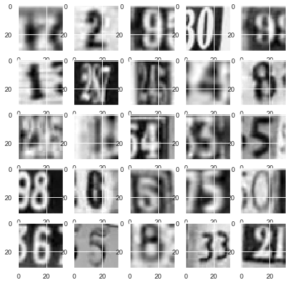

```python
fig=plt.figure(figsize=(8,8))
columns=5
rows=5
for i in range(1, columns*rows+1):
    img=X_test[i]
    fig.add_subplot(rows,columns,i)
    print("Label = "+str(y_test[i]))
    plt.imshow(img,cmap='gray')
plt.show()
```

## Data Preprocessing

### Reshaping from 2d to 1d

```python
X_train = np.array(X_train).reshape(42000,1024)
```

```python
X_train.shape
```

```
(42000, 1024)
```

```python
X_test = np.array(X_test).reshape(18000,1024)
```

```python
X_test.shape
```

```
(18000, 1024)
```

```python
X_val = np.array(X_val).reshape(60000,1024)
```

```python
X_val.shape
```

```
(60000, 1024)
```

### Converting labels to categorical

```python
from keras.utils.np_utils import to_categorical
y_train = to_categorical(y_train,num_classes=None)
y_test = to_categorical(y_test,num_classes=None)
y_val = to_categorical(y_val, num_classes=None)
```

```python
print(y_train.shape)
print(y_test.shape)
print(y_val.shape)
```

```
(42000, 10)
(18000, 10)
(60000, 10)
```

### Training neural network

```python
def create_model():
    model = Sequential()
    model.add(Dense(512, input_dim=1024, kernel_initializer='normal', activation='relu'))
    #model.add(Dropout(0.5))
    model.add(Dense(256, kernel_initializer='normal',activation='relu'))
    #model.add(Dropout(0.5))
    model.add(Dense(128, kernel_initializer='normal',activation='relu'))
    #model.add(Dropout(0.5))
    model.add(Dense(64, kernel_initializer='normal',activation='relu'))
    #model.add(Dropout(0.5))
    model.add(Dense(32, kernel_initializer='normal',activation='relu'))
    #model.add(Dropout(0.5))
    model.add(Dense(10,activation='softmax'))
    model.summary()
    return model
```

### Using adam optimizer

```python
model = create_model()
model.compile(loss='categorical_crossentropy', optimizer='adam', metrics=['accuracy'])
history = model.fit(X_train, y_train, validation_data=(X_val,y_val), epochs=200, batch_size=100,  verbose=1, validation_split=0.2)
```

```
Model: "sequential_6"
_________________________________________________________________
Layer (type)                 Output Shape              Param #
=================================================================
dense_36 (Dense)             (None, 512)               524800
_________________________________________________________________
dense_37 (Dense)             (None, 256)               131328
_________________________________________________________________
dense_38 (Dense)             (None, 128)               32896
_________________________________________________________________
dense_39 (Dense)             (None, 64)                8256
_________________________________________________________________
dense_40 (Dense)             (None, 32)                2080
_________________________________________________________________
dense_41 (Dense)             (None, 10)                330
=================================================================
Total params: 699,690
Trainable params: 699,690
Non-trainable params: 0
_________________________________________________________________
Train on 42000 samples, validate on 60000 samples
```

```
dict_keys(['loss', 'acc', 'val_loss', 'val_acc'])
```

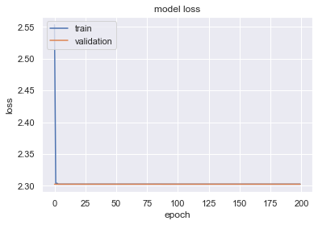

```python
print(history.history.keys())
plt.plot(history.history['loss'])
plt.plot(history.history['val_loss'])
plt.title('model loss')
plt.ylabel('loss')
plt.xlabel('epoch')
plt.legend(['train', 'validation'], loc='upper left')
plt.show()
```

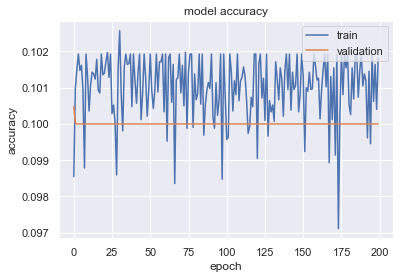

```python
plt.plot(history.history['acc'])
plt.plot(history.history['val_acc'])
plt.title('model accuracy')
plt.ylabel('accuracy')
plt.xlabel('epoch')
plt.legend(['train', 'validation'], loc='upper right')
plt.show()
```

**Observations:**

We do not see any improvement in the validation loss over each epoch.

We will try to tweak the learning rate of the adam optimizer and see the results.

We will also use he_normal as the weight initializer.

This initailizer draws samples from a truncated normal distribution centered on 0 with stddev = sqrt(2 / fan_in) where fan_in is the number of input units in the weight tensor.

```python
import tensorflow as tf
opt = tf.keras.optimizers.Adam(
    learning_rate=0.0001, beta_1=0.9, beta_2=0.999, epsilon=1e-07, amsgrad=False,
    name='Adam')
```

```python
initializer = tf.keras.initializers.he_normal()
```

```python
model = Sequential()
model.add(Dense(512, input_dim=1024, kernel_initializer=initializer, activation='relu'))
model.add(Dense(256, kernel_initializer=initializer,activation='relu'))
model.add(Dense(128, kernel_initializer=initializer,activation='relu'))
model.add(Dense(64, kernel_initializer=initializer,activation='relu'))
model.add(Dense(32, kernel_initializer=initializer,activation='relu'))
model.add(Dense(10,activation='softmax'))
model.summary()
```

```
Model: "sequential_9"
_________________________________________________________________
Layer (type)                 Output Shape              Param #
=================================================================
dense_48 (Dense)             (None, 512)               524800
_________________________________________________________________
dense_49 (Dense)             (None, 256)               131328
_________________________________________________________________
dense_50 (Dense)             (None, 128)               32896
_________________________________________________________________
dense_51 (Dense)             (None, 64)                8256
_________________________________________________________________
dense_52 (Dense)             (None, 32)                2080
_________________________________________________________________
dense_53 (Dense)             (None, 10)                330
=================================================================
Total params: 699,690
Trainable params: 699,690
Non-trainable params: 0
_________________________________________________________________
```

```python
model.compile(loss='categorical_crossentropy', optimizer=opt, metrics=['accuracy'])
history = model.fit(X_train, y_train, validation_data=(X_val,y_val),epochs=200, batch_size=100,  verbose=1, validation_split=0.2)
```

```
Train on 42000 samples, validate on 60000 samples
```

```
dict_keys(['loss', 'acc', 'val_loss', 'val_acc'])
```

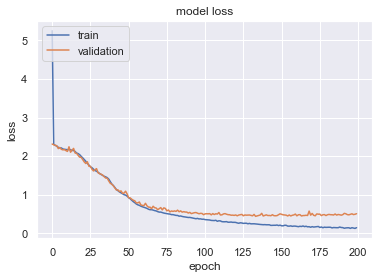

```python
print(history.history.keys())
plt.plot(history.history['loss'])
plt.plot(history.history['val_loss'])
plt.title('model loss')
plt.ylabel('loss')
plt.xlabel('epoch')
plt.legend(['train', 'validation'], loc='upper left')
plt.show()
```

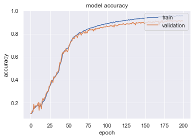

```python
plt.plot(history.history['acc'])
plt.plot(history.history['val_acc'])
plt.title('model accuracy')
plt.ylabel('accuracy')
plt.xlabel('epoch')
plt.legend(['train', 'validation'], loc='upper right')
plt.show()
```

```python
y_pred = model.predict_classes(X_test)
y_classes = [np.argmax(y, axis=None, out=None) for y in y_test]
```

```python
from sklearn.metrics import classification_report
print(classification_report(y_pred,y_classes))
```

```
              precision    recall  f1-score   support

           0       0.83      0.86      0.84      1744
           1       0.82      0.80      0.81      1872
           2       0.83      0.80      0.82      1866
           3       0.77      0.76      0.77      1741
           4       0.84      0.83      0.84      1844
           5       0.77      0.80      0.78      1715
           6       0.79      0.82      0.80      1762
           7       0.85      0.84      0.85      1819
           8       0.77      0.74      0.75      1887
           9       0.78      0.81      0.80      1750

    accuracy                           0.81     18000
   macro avg       0.81      0.81      0.81     18000
weighted avg       0.81      0.81      0.81     18000
```

**Observations:**

Earlier we used 'normal' weight initializer but we did not see much imporvement but after we used he_normal initalizers there was a significant improvement in the cross val accuracy.

The f1 and recall score on test data is 0.81

**This shows that along with learning rate weight initializers are also important when it comes to improving the accuracy of the model.**

### Using dropout layers with dropout rate = 0.25 with adam optimizer

```python
opt = tf.keras.optimizers.Adam(
    learning_rate=0.0001, beta_1=0.9, beta_2=0.999, epsilon=1e-07, amsgrad=False,
    name='Adam')
```

```python
model = Sequential()
model.add(Dense(512, input_dim=1024, kernel_initializer=initializer, activation='relu'))
model.add(Dropout(0.25))
model.add(Dense(256, kernel_initializer=initializer,activation='relu'))
model.add(Dropout(0.25))
model.add(Dense(128, kernel_initializer=initializer,activation='relu'))
model.add(Dropout(0.25))
model.add(Dense(64, kernel_initializer=initializer,activation='relu'))
model.add(Dropout(0.25))
model.add(Dense(32, kernel_initializer=initializer,activation='relu'))
model.add(Dropout(0.25))
model.add(Dense(10,activation='softmax'))
model.summary()
```

```
Model: "sequential_12"
_________________________________________________________________
Layer (type)                 Output Shape              Param #
=================================================================
dense_66 (Dense)             (None, 512)               524800
_________________________________________________________________
dropout_40 (Dropout)         (None, 512)               0
_________________________________________________________________
dense_67 (Dense)             (None, 256)               131328
_________________________________________________________________
dropout_41 (Dropout)         (None, 256)               0
_________________________________________________________________
dense_68 (Dense)             (None, 128)               32896
_________________________________________________________________
dropout_42 (Dropout)         (None, 128)               0
_________________________________________________________________
dense_69 (Dense)             (None, 64)                8256
_________________________________________________________________
dropout_43 (Dropout)         (None, 64)                0
_________________________________________________________________
dense_70 (Dense)             (None, 32)                2080
_________________________________________________________________
dropout_44 (Dropout)         (None, 32)                0
_________________________________________________________________
dense_71 (Dense)             (None, 10)                330
=================================================================
Total params: 699,690
Trainable params: 699,690
Non-trainable params: 0
_________________________________________________________________
```

```python
model.compile(loss='categorical_crossentropy', optimizer=opt, metrics=['accuracy'])
history = model.fit(X_train, y_train, validation_data=(X_val,y_val),epochs=200, batch_size=100,  verbose=1, validation_split=0.2)
```

```
Train on 42000 samples, validate on 60000 samples
```

```
dict_keys(['loss', 'acc', 'val_loss', 'val_acc'])
```

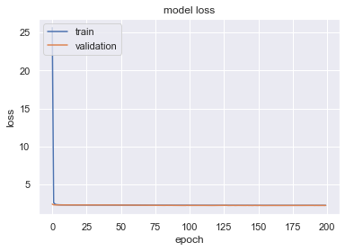

```python
print(history.history.keys())
plt.plot(history.history['loss'])
plt.plot(history.history['val_loss'])
plt.title('model loss')
plt.ylabel('loss')
plt.xlabel('epoch')
plt.legend(['train', 'validation'], loc='upper left')
plt.show()
```

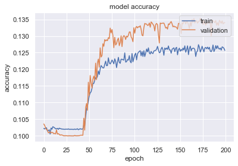

```python
plt.plot(history.history['acc'])
plt.plot(history.history['val_acc'])
plt.title('model accuracy')
plt.ylabel('accuracy')
plt.xlabel('epoch')
plt.legend(['train', 'validation'], loc='upper right')
plt.show()
```

```python
y_pred = model.predict_classes(X_test)
y_classes = [np.argmax(y, axis=None, out=None) for y in y_test]
```

```python
from sklearn.metrics import classification_report
print(classification_report(y_pred,y_classes))
```

```
              precision    recall  f1-score   support

           0       0.00      0.00      0.00         0
           1       0.09      0.24      0.13       673
           2       0.00      0.00      0.00         0
           3       0.97      0.10      0.18     16302
           4       0.28      0.50      0.36      1015
           5       0.00      0.00      0.00         0
           6       0.00      0.00      0.00        10
           7       0.00      0.00      0.00         0
           8       0.00      0.00      0.00         0
           9       0.00      0.00      0.00         0

    accuracy                           0.13     18000
   macro avg       0.13      0.08      0.07     18000
weighted avg       0.89      0.13      0.19     18000
```

### Using glorot normal as the initializer and adam optimizer with learning rate = 0.0001

This initializer draws samples from a truncated normal distribution centered on 0 with stddev = sqrt(2 / (fan_in + fan_out)) where fan_in is the number of input units in the weight tensor and fan_out is the number of output units in the weight tensor.

```python
glorot_normal = tf.keras.initializers.glorot_normal
```

```python
model = Sequential()
model.add(Dense(512, input_dim=1024, kernel_initializer=glorot_normal, activation='relu'))
model.add(Dense(256, kernel_initializer=glorot_normal,activation='relu'))
model.add(Dense(128, kernel_initializer=glorot_normal,activation='relu'))
model.add(Dense(64, kernel_initializer=glorot_normal,activation='relu'))
model.add(Dense(32, kernel_initializer=glorot_normal,activation='relu'))
model.add(Dense(10,activation='softmax'))
model.summary()
```

```
Model: "sequential_14"
_________________________________________________________________
Layer (type)                 Output Shape              Param #
=================================================================
dense_78 (Dense)             (None, 512)               524800
_________________________________________________________________
dense_79 (Dense)             (None, 256)               131328
_________________________________________________________________
dense_80 (Dense)             (None, 128)               32896
_________________________________________________________________
dense_81 (Dense)             (None, 64)                8256
_________________________________________________________________
dense_82 (Dense)             (None, 32)                2080
_________________________________________________________________
dense_83 (Dense)             (None, 10)                330
=================================================================
Total params: 699,690
Trainable params: 699,690
Non-trainable params: 0
_________________________________________________________________
```

```python
model.compile(loss='categorical_crossentropy', optimizer=opt, metrics=['accuracy'])
history = model.fit(X_train, y_train, validation_data=(X_val,y_val),epochs=200, batch_size=100,  verbose=1, validation_split=0.2)
```

```
Train on 42000 samples, validate on 60000 samples
```

```
dict_keys(['loss', 'acc', 'val_loss', 'val_acc'])
```

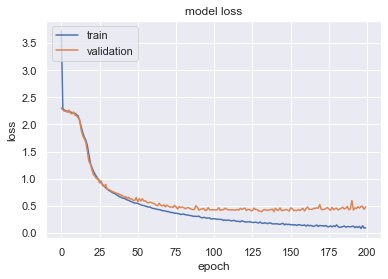

```python
print(history.history.keys())
plt.plot(history.history['loss'])
plt.plot(history.history['val_loss'])
plt.title('model loss')
plt.ylabel('loss')
plt.xlabel('epoch')
plt.legend(['train', 'validation'], loc='upper left')
plt.show()
```

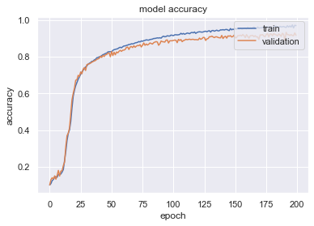

```python
plt.plot(history.history['acc'])
plt.plot(history.history['val_acc'])
plt.title('model accuracy')
plt.ylabel('accuracy')
plt.xlabel('epoch')
plt.legend(['train', 'validation'], loc='upper right')
plt.show()
```

```python
y_pred = model.predict_classes(X_test)
y_classes = [np.argmax(y, axis=None, out=None) for y in y_test]
print(classification_report(y_pred,y_classes))
```

```
              precision    recall  f1-score   support

           0       0.86      0.82      0.84      1913
           1       0.82      0.83      0.82      1803
           2       0.82      0.85      0.84      1726
           3       0.73      0.81      0.77      1549
           4       0.86      0.83      0.85      1880
           5       0.79      0.81      0.80      1709
           6       0.81      0.79      0.80      1873
           7       0.85      0.85      0.85      1807
           8       0.75      0.80      0.77      1703
           9       0.84      0.75      0.79      2037

    accuracy                           0.81     18000
   macro avg       0.81      0.81      0.81     18000
weighted avg       0.81      0.81      0.81     18000
```

## Let us try stochastic gradient descent with nestrov momentum

Usually sgd optimizer converges to the optimal solution slowly.Nestrov momentum will help to converge faster.

Weight initializer could be either glorot normal or he_normal

```python
from tensorflow import keras
sgd = keras.optimizers.SGD(lr=0.0001, momentum=0.8, nesterov=True)
```

```python
model_s = Sequential()
model_s.add(Dense(512, input_dim=1024, kernel_initializer=tf.keras.initializers.glorot_normal, activation='relu'))
model_s.add(Dense(256, kernel_initializer=tf.keras.initializers.glorot_normal,activation='relu'))
model_s.add(Dense(128, kernel_initializer=tf.keras.initializers.glorot_normal,activation='relu'))
model_s.add(Dense(64, kernel_initializer=tf.keras.initializers.glorot_normal,activation='relu'))
model_s.add(Dense(32, kernel_initializer=tf.keras.initializers.glorot_normal,activation='relu'))
model_s.add(Dense(10,activation='softmax'))
model_s.summary()
```

```
Model: "sequential_25"
_________________________________________________________________
Layer (type)                 Output Shape              Param #
=================================================================
dense_134 (Dense)            (None, 512)               524800
_________________________________________________________________
dense_135 (Dense)            (None, 256)               131328
_________________________________________________________________
dense_136 (Dense)            (None, 128)               32896
_________________________________________________________________
dense_137 (Dense)            (None, 64)                8256
_________________________________________________________________
dense_138 (Dense)            (None, 32)                2080
_________________________________________________________________
dense_139 (Dense)            (None, 10)                330
=================================================================
Total params: 699,690
Trainable params: 699,690
Non-trainable params: 0
_________________________________________________________________
```

```python
model_s.compile(loss='categorical_crossentropy', optimizer=sgd, metrics=['accuracy'])
history = model_s.fit(X_train, y_train, validation_data=(X_val,y_val),epochs=100, batch_size=100,  verbose=1, validation_split=0.2)
```

```
Train on 42000 samples, validate on 60000 samples
```

```
dict_keys(['loss', 'acc', 'val_loss', 'val_acc'])
```

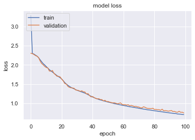

```python
print(history.history.keys())
plt.plot(history.history['loss'])
plt.plot(history.history['val_loss'])
plt.title('model loss')
plt.ylabel('loss')
plt.xlabel('epoch')
plt.legend(['train', 'validation'], loc='upper left')
plt.show()
```

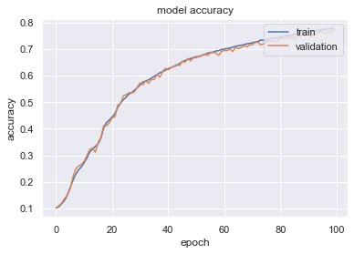

```python
plt.plot(history.history['acc'])
plt.plot(history.history['val_acc'])
plt.title('model accuracy')
plt.ylabel('accuracy')
plt.xlabel('epoch')
plt.legend(['train', 'validation'], loc='upper right')
plt.show()
```

```python
y_pred = model_s.predict_classes(X_test)
y_classes = [np.argmax(y, axis=None, out=None) for y in y_test]
print(classification_report(y_pred,y_classes))
```

```
              precision    recall  f1-score   support

           0       0.78      0.74      0.76      1928
           1       0.72      0.79      0.75      1671
           2       0.75      0.79      0.77      1717
           3       0.68      0.72      0.70      1628
           4       0.81      0.78      0.80      1892
           5       0.73      0.68      0.70      1903
           6       0.74      0.71      0.72      1924
           7       0.77      0.77      0.77      1826
           8       0.60      0.72      0.66      1528
           9       0.75      0.69      0.72      1983

    accuracy                           0.74     18000
   macro avg       0.74      0.74      0.73     18000
weighted avg       0.74      0.74      0.74     18000
```

#### SGD with nestrov momentum does not show much improvement. Lets try SGD without momentum

```python
model = Sequential()
model.add(Dense(512, input_dim=1024, kernel_initializer=glorot_normal, activation='relu'))
model.add(Dense(256, kernel_initializer=glorot_normal,activation='relu'))
model.add(Dense(128, kernel_initializer=glorot_normal,activation='relu'))
model.add(Dense(64, kernel_initializer=glorot_normal,activation='relu'))
model.add(Dense(32, kernel_initializer=glorot_normal,activation='relu'))
model.add(Dense(10,activation='softmax'))
model.summary()
```

```
Model: "sequential_16"
_________________________________________________________________
Layer (type)                 Output Shape              Param #
=================================================================
dense_90 (Dense)             (None, 512)               524800
_________________________________________________________________
dense_91 (Dense)             (None, 256)               131328
_________________________________________________________________
dense_92 (Dense)             (None, 128)               32896
_________________________________________________________________
dense_93 (Dense)             (None, 64)                8256
_________________________________________________________________
dense_94 (Dense)             (None, 32)                2080
_________________________________________________________________
dense_95 (Dense)             (None, 10)                330
=================================================================
Total params: 699,690
Trainable params: 699,690
Non-trainable params: 0
_________________________________________________________________
```

```python
sgd = keras.optimizers.SGD(lr=0.0001)
```

```python
model.compile(loss='categorical_crossentropy', optimizer=sgd, metrics=['accuracy'])
history = model.fit(X_train, y_train, validation_data=(X_val,y_val),epochs=200, batch_size=100,  verbose=1, validation_split=0.2)
```

```
Train on 42000 samples, validate on 60000 samples
```

```
dict_keys(['loss', 'acc', 'val_loss', 'val_acc'])
```

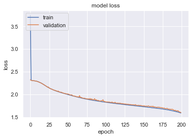

```python
print(history.history.keys())
plt.plot(history.history['loss'])
plt.plot(history.history['val_loss'])
plt.title('model loss')
plt.ylabel('loss')
plt.xlabel('epoch')
plt.legend(['train', 'validation'], loc='upper left')
plt.show()
```

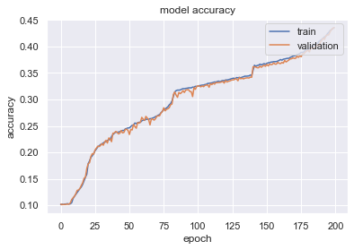

```python
plt.plot(history.history['acc'])
plt.plot(history.history['val_acc'])
plt.title('model accuracy')
plt.ylabel('accuracy')
plt.xlabel('epoch')
plt.legend(['train', 'validation'], loc='upper right')
plt.show()
```

#### As exepected the convergence without momentum is very slow. Let us try ADAM optimizer with batch normalization

```python
from tensorflow.keras.layers import BatchNormalization
```

```python
model = Sequential()
model.add(Dense(512, input_dim=1024, kernel_initializer=glorot_normal, activation='relu'))
model.add(BatchNormalization())
model.add(Dense(256, kernel_initializer=glorot_normal,activation='relu'))
model.add(BatchNormalization())
model.add(Dense(128, kernel_initializer=glorot_normal,activation='relu'))
model.add(BatchNormalization())
model.add(Dense(64, kernel_initializer=glorot_normal,activation='relu'))
model.add(BatchNormalization())
model.add(Dense(32, kernel_initializer=glorot_normal,activation='relu'))
model.add(BatchNormalization())
model.add(Dense(10,activation='softmax'))
model.summary()
```

```
Model: "sequential_19"
_________________________________________________________________
Layer (type)                 Output Shape              Param #
=================================================================
dense_103 (Dense)            (None, 512)               524800
_________________________________________________________________
batch_normalization (BatchNo (None, 512)               2048
_________________________________________________________________
dense_104 (Dense)            (None, 256)               131328
_________________________________________________________________
batch_normalization_1 (Batch (None, 256)               1024
_________________________________________________________________
dense_105 (Dense)            (None, 128)               32896
_________________________________________________________________
batch_normalization_2 (Batch (None, 128)               512
_________________________________________________________________
dense_106 (Dense)            (None, 64)                8256
_________________________________________________________________
batch_normalization_3 (Batch (None, 64)                256
_________________________________________________________________
dense_107 (Dense)            (None, 32)                2080
_________________________________________________________________
batch_normalization_4 (Batch (None, 32)                128
_________________________________________________________________
dense_108 (Dense)            (None, 10)                330
=================================================================
Total params: 703,658
Trainable params: 701,674
Non-trainable params: 1,984
_________________________________________________________________
```

```python
model.compile(loss='categorical_crossentropy', optimizer=opt, metrics=['accuracy'])
history = model.fit(X_train, y_train, validation_data=(X_val,y_val),epochs=200, batch_size=100,  verbose=1, validation_split=0.2)
```

```
Train on 42000 samples, validate on 60000 samples
```

```
dict_keys(['loss', 'acc', 'val_loss', 'val_acc'])
```

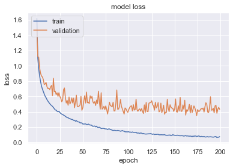

```python
print(history.history.keys())
plt.plot(history.history['loss'])
plt.plot(history.history['val_loss'])
plt.title('model loss')
plt.ylabel('loss')
plt.xlabel('epoch')
plt.legend(['train', 'validation'], loc='upper left')
plt.show()
```

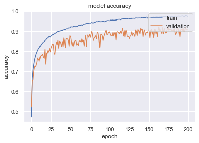

```python
plt.plot(history.history['acc'])
plt.plot(history.history['val_acc'])
plt.title('model accuracy')
plt.ylabel('accuracy')
plt.xlabel('epoch')
plt.legend(['train', 'validation'], loc='upper right')
plt.show()
```

```python
y_pred = model.predict_classes(X_test)
y_classes = [np.argmax(y, axis=None, out=None) for y in y_test]
print(classification_report(y_pred,y_classes))
```

```
              precision    recall  f1-score   support

           0       0.83      0.87      0.85      1737
           1       0.76      0.85      0.80      1631
           2       0.83      0.84      0.84      1791
           3       0.77      0.77      0.77      1718
           4       0.80      0.90      0.85      1609
           5       0.80      0.80      0.80      1772
           6       0.77      0.85      0.81      1648
           7       0.85      0.84      0.84      1837
           8       0.84      0.66      0.74      2312
           9       0.82      0.76      0.79      1945

    accuracy                           0.81     18000
   macro avg       0.81      0.81      0.81     18000
weighted avg       0.81      0.81      0.81     18000
```

```python
model1 = Sequential()
model1.add(Dense(512, input_dim=1024, kernel_initializer=glorot_normal, activation='relu'))
model1.add(BatchNormalization())
model1.add(Dense(256, kernel_initializer=glorot_normal,activation='relu'))
model1.add(BatchNormalization())
model1.add(Dense(128, kernel_initializer=glorot_normal,activation='relu'))
model1.add(BatchNormalization())
model1.add(Dense(64, kernel_initializer=glorot_normal,activation='relu'))
model1.add(BatchNormalization())
model1.add(Dense(32, kernel_initializer=glorot_normal,activation='relu'))
model1.add(BatchNormalization())
model1.add(Dense(10,activation='softmax'))
model1.summary()
```

```
Model: "sequential_21"
_________________________________________________________________
Layer (type)                 Output Shape              Param #
=================================================================
dense_115 (Dense)            (None, 512)               524800
_________________________________________________________________
batch_normalization_10 (Batc (None, 512)               2048
_________________________________________________________________
dense_116 (Dense)            (None, 256)               131328
_________________________________________________________________
batch_normalization_11 (Batc (None, 256)               1024
_________________________________________________________________
dense_117 (Dense)            (None, 128)               32896
_________________________________________________________________
batch_normalization_12 (Batc (None, 128)               512
_________________________________________________________________
dense_118 (Dense)            (None, 64)                8256
_________________________________________________________________
batch_normalization_13 (Batc (None, 64)                256
_________________________________________________________________
dense_119 (Dense)            (None, 32)                2080
_________________________________________________________________
batch_normalization_14 (Batc (None, 32)                128
_________________________________________________________________
dense_120 (Dense)            (None, 10)                330
=================================================================
Total params: 703,658
Trainable params: 701,674
Non-trainable params: 1,984
_________________________________________________________________
```

```python
from tensorflow import keras
sgd = keras.optimizers.SGD(lr=0.0001, momentum=0.8, nesterov=True)
```

```python
model1.compile(loss='categorical_crossentropy', optimizer=opt, metrics=['accuracy'])
history = model1.fit(X_train, y_train, validation_data=(X_val,y_val),epochs=100, batch_size=100,  verbose=1, validation_split=0.2)
```

```
Train on 42000 samples, validate on 60000 samples
```

```
dict_keys(['loss', 'acc', 'val_loss', 'val_acc'])
```

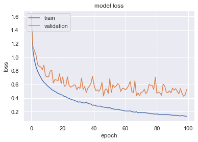

```python
print(history.history.keys())
plt.plot(history.history['loss'])
plt.plot(history.history['val_loss'])
plt.title('model loss')
plt.ylabel('loss')
plt.xlabel('epoch')
plt.legend(['train', 'validation'], loc='upper left')
plt.show()
```

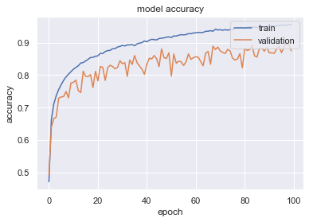

```python
plt.plot(history.history['acc'])
plt.plot(history.history['val_acc'])
plt.title('model accuracy')
plt.ylabel('accuracy')
plt.xlabel('epoch')
plt.legend(['train', 'validation'], loc='upper right')
plt.show()
```

```python
y_pred = model1.predict_classes(X_test)
y_classes = [np.argmax(y, axis=None, out=None) for y in y_test]
print(classification_report(y_pred,y_classes))
```

```
              precision    recall  f1-score   support

           0       0.82      0.85      0.83      1762
           1       0.83      0.71      0.76      2133
           2       0.84      0.75      0.79      2021
           3       0.75      0.76      0.76      1692
           4       0.83      0.84      0.83      1780
           5       0.76      0.82      0.79      1647
           6       0.79      0.80      0.80      1809
           7       0.77      0.91      0.83      1517
           8       0.81      0.74      0.78      1971
           9       0.77      0.83      0.80      1668

    accuracy                           0.80     18000
   macro avg       0.80      0.80      0.80     18000
weighted avg       0.80      0.80      0.80     18000
```

### Predicting random test data with model trained with adam optimizer with learning rate = 0.0001 and with batchnormalization layer

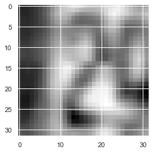

```python
plt.imshow(X_test[91].reshape(32,32), cmap='gray')
```

```python
print("Actual Label = "+str(np.argmax(y_test[91], axis=None, out=None)))
y_pr = model.predict_classes(X_test)[91]
print("Predicted Label = "+str(y_pr))
```

```
Actual Label = 2
Predicted Label = 2
```

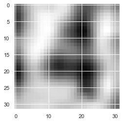

```python
plt.imshow(X_test[9].reshape(32,32), cmap='gray')
```

```python
print("Actual Label = "+str(np.argmax(y_test[9], axis=None, out=None)))
y_pr = model.predict_classes(X_test)[9]
print("Predicted Label = "+str(y_pr))
```

```
Actual Label = 4
Predicted Label = 4
```

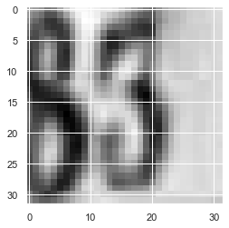

```python
plt.imshow(X_test[928].reshape(32,32), cmap='gray')
```

```python
print("Actual Label = "+str(np.argmax(y_test[928], axis=None, out=None)))
y_pr = model.predict_classes(X_test)[928]
print("Predicted Label = "+str(y_pr))
```

```
Actual Label = 3
Predicted Label = 3
```

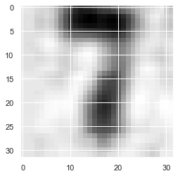

```python
plt.imshow(X_test[9289].reshape(32,32), cmap='gray')
```

```python
print("Actual Label = "+str(np.argmax(y_test[9289], axis=None, out=None)))
y_pr = model.predict_classes(X_test)[9289]
print("Predicted Label = "+str(y_pr))
```

```
Actual Label = 7
Predicted Label = 7
```

**Final Conclusion:**

Overall the model trained with adam optimizer performs better than sgd.

Our models performed better when either he_normal or glorot_normal were used as weight initializers.

Introducing dropout layers while training did not help in improving the performance of the model rather it seemed to have detoriated the performance overall.

We picked the adam optimized model with batch normalisation and predicted random images correctly as shown above.